[figure not shown]

# Master en Data Science - Trabajo Final de Máster:

# **MODELOS CAUSALES DE MACHINE LEARNING**

# **6. Explicabilidad**

##### Autor: Rodrigo Fernandez Campos

### DataSet: IBM - Telco Customer Churn

En este notebook final se realizará la exposición de la explicabilidad de los modelos predictivos, tanto del LightGBM como de la Regresión Logística, cuyo análisis es más bien de interpretabilidad directamente. Sumado a esto, se realizará un agregado de valor a este análisis, en donde se utilizará una metodología de clustering con el fin de generar estrategias de negocio para ofrecer soluciones efectivas a la fuga de clientes, combinando propensión a fraude con el uso del tratamiento en base a los resultados del modelado causal.

## Librerías y funciones

Sección en la que se importan las librerías públicas y también se importan funciones personalizadas desde un script propio.

```python
# Manipulación de datos
import pandas as pd
import numpy as np
import matplotlib.pyplot as plt
import seaborn as sns
import sys
import importlib
import warnings
import joblib

# Explicabilidad e interpretabilidad
import shap
shap.initjs()
from sklearn.linear_model import LinearRegression
from sklearn.cluster import KMeans

# Configs
warnings.filterwarnings('ignore')
pd.set_option('display.max_columns', 500)
pd.set_option('display.max_rows', 500)

seed=10
```

```python
sys.path.append('../src/')
import functions_rfc_IBM as fr
importlib.reload(fr)
sys.path.remove('../src/')
```

## Importando dataset y modelos

En este caso se importan los sets de train y test ya preprocesados, además del df con las probabilidades de fraude y los CATE calculados anteriormente, más los modelos entrenados.

```python
df_train = pd.read_parquet('../data/ibm_telco_churn/processed/df_train_processed.parquet')
df_test = pd.read_parquet('../data/ibm_telco_churn/processed/df_test_processed.parquet')
df_cates = pd.read_parquet('../data/ibm_telco_churn/processed/df_cates.parquet')
```

```python
df_train.head()
```

|  | Tenure Months | Monthly Charges | CLTV | Contract | Payment Method | Senior Citizen | Partner | Dependents | Phone Service | Internet Service | Online Security | Online Backup | Device Protection | Tech Support | Paperless Billing | Churn Value |
| --- | --- | --- | --- | --- | --- | --- | --- | --- | --- | --- | --- | --- | --- | --- | --- | --- |
| 2125 | -1.299099 | -0.217742 | 0.018351 | 0.0 | 0.471083 | 1.0 | 0.0 | 0.0 | 1.0 | 1.0 | 0.0 | 0.0 | 0.0 | 0.0 | 1.0 | 0 |
| 6768 | 0.411249 | -2.175807 | 0.280323 | 0.0 | 0.190022 | 0.0 | 1.0 | 1.0 | 0.0 | 0.0 | 0.0 | 1.0 | 0.0 | 0.0 | 0.0 | 0 |
| 6796 | -0.118144 | 0.111652 | -1.488203 | 1.0 | 0.190022 | 0.0 | 0.0 | 0.0 | 1.0 | 0.0 | 1.0 | 0.0 | 1.0 | 0.0 | 1.0 | 0 |
| 476 | 0.981365 | -1.464407 | 0.645728 | 0.0 | 0.471083 | 1.0 | 1.0 | 0.0 | 0.0 | 0.0 | 0.0 | 0.0 | 0.0 | 0.0 | 1.0 | 1 |
| 6706 | -0.932596 | -0.151406 | 0.020046 | 1.0 | 0.190022 | 0.0 | 0.0 | 1.0 | 1.0 | 0.0 | 1.0 | 0.0 | 1.0 | 1.0 | 0.0 | 0 |

```python
X_train = df_train.drop('Churn Value', axis=1)
y_train = df_train['Churn Value']

X_test = df_test.drop('Churn Value', axis=1)
y_test = df_test['Churn Value']
```

```python
lgbm = joblib.load('../models/lgbm_model.joblib')
lr = joblib.load('../models/logistic_regression_model.joblib')
xlearner = joblib.load('../models/Xlearner_model.joblib')
```

## Shap values

Mediante el uso de la librería SHAP se procede a calcular los Shap Values que permitirán explicar el funcionamiento del modelo predictivo de Boosting elegido, el LightGBM

```python
explainer_lgbm = shap.TreeExplainer(lgbm)
```

```python
%%time
shap_values = explainer_lgbm.shap_values(X_test)
```

```
CPU times: total: 188 ms
Wall time: 57.2 ms
```

# Explicabilidad

La explicabilidad del modelo LightGBM podrá dividirse en 3 secciones principales:

1. Una primera sección en donde se analizarán los comportamientos de algunas de las principales variables del modelo mediante el uso de graficos de dependencia parcial.
2. Una segunda sección en donde se verifica el potencial de explicabilidad local del modelo, en donde básicamente se busca entender cómo afecta cada característica de cada instancia al score de propención a la fuga asignado por el modelo.
3. Finalmente se detalla la explicabilidad global, en la que se expone la influencia de cada una de las variables en las decisiones en general del modelo predictivo.

## 1. Gráficos de dependencia parcial

En este apartado se proceden a generar los gráficos de dependencia parcial de variables importantes para las decisiones del modelo, además de claro, la variable treatmen:

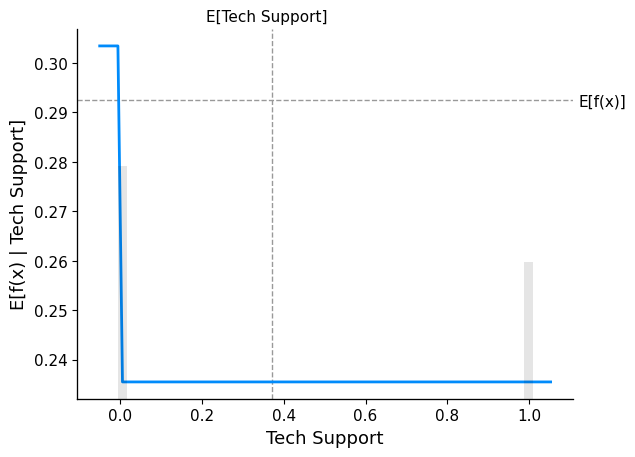

```
CPU times: total: 1.02 s
Wall time: 949 ms
```

```python
%%time
shap.partial_dependence_plot(
    "Tech Support",
    lgbm.predict,
    data=X_test,
    ice=False,
    model_expected_value=True,
    feature_expected_value=True,
)
```

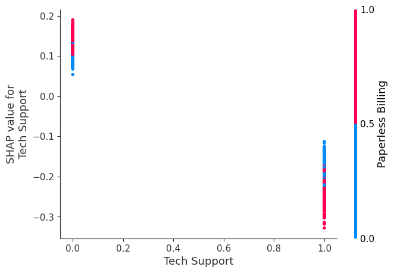

```python
shap.dependence_plot('Tech Support', shap_values[1], X_test)
```

Lo primero que se puede observar es que la variable tratamiento, que en este dataset en concreto es un booleano que indica si el cliente posee el servicio técnico premium o no, parece influír, como se vió en el análisis causal, de manera negativa en el output del modelo. Es decir, que si Tech Support es 1, por ende el cliente posee el servicio técnico, la propención a la fuga será menor que si no lo tuviese.

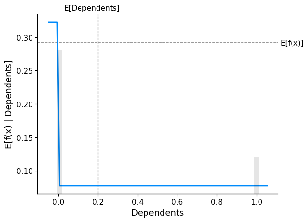

```
CPU times: total: 641 ms
Wall time: 669 ms
```

```python
%%time
shap.partial_dependence_plot(
    "Dependents",
    lgbm.predict,
    data=X_test,
    ice=False,
    model_expected_value=True,
    feature_expected_value=True,
)
```

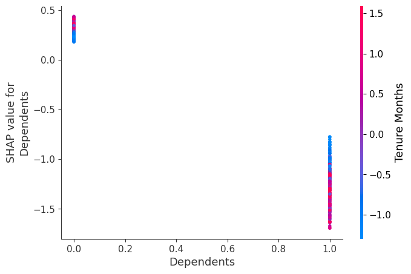

```python
shap.dependence_plot('Dependents', shap_values[1], X_test)
```

Algo muy similar a lo mencionado para Tech Support, pero en mayor escala sucede con la variable Dependents. Esto quiere decir que si el cliente tiene personas a su cargo, es bastante menos probable que su propención a la fuga sea alta comparado con quienes no tienen persona a su cargo.

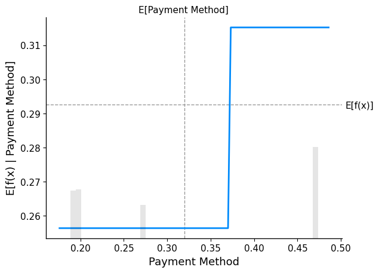

```
CPU times: total: 719 ms
Wall time: 867 ms
```

```python
%%time
shap.partial_dependence_plot(
    "Payment Method",
    lgbm.predict,
    data=X_test,
    ice=False,
    model_expected_value=True,
    feature_expected_value=True,
)
```

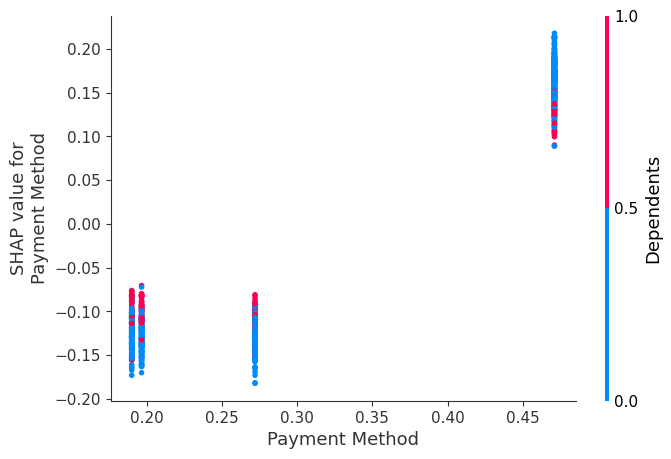

```python
shap.dependence_plot('Payment Method', shap_values[1], X_test)
```

```python
payment_method_original = pd.read_parquet('../data/ibm_telco_churn/df_telco_test.parquet')['Payment Method'].value_counts().reset_index()
```

```python
(payment_method_original.merge(X_test['Payment Method'].value_counts().reset_index()
                               ,on='count'
                               ,suffixes=('_original', '_processed'))
                        .sort_values(by='Payment Method_processed', ascending=False)
)
```

|  | Payment Method_original | count | Payment Method_processed |
| --- | --- | --- | --- |
| 0 | Electronic check | 456 | 0.471083 |
| 3 | Mailed check | 165 | 0.272015 |
| 1 | Bank transfer (automatic) | 245 | 0.196576 |
| 2 | Credit card (automatic) | 238 | 0.190022 |

Para comprender mejor los valores del gráfico se ha recuperado el encoding realizado de la variable método de pago. En este caso se puede notar como, al igual que ya se había visto en el EDA, quienes utilizan como método de pago el cheque electrónico tienen claramente una mayor propención a fuga que quienes usan los demás métodos de pago. Este puede ser un tema a revisar por parte de la empresa, ya que puede que sea un medio que esté generando dificultades o disconformidades en los clientes.

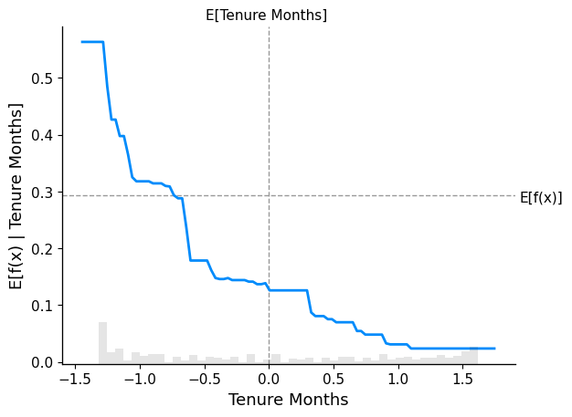

```
CPU times: total: 1.28 s
Wall time: 1.02 s
```

```python
%%time
shap.partial_dependence_plot(
    "Tenure Months",
    lgbm.predict,
    data=X_test,
    ice=False,
    model_expected_value=True,
    feature_expected_value=True,
)
```

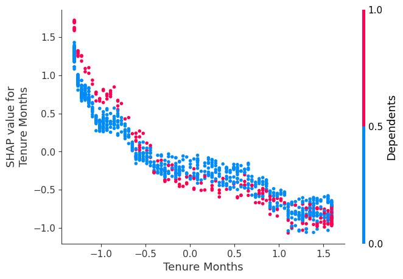

```python
shap.dependence_plot('Tenure Months', shap_values[1], X_test)
```

Finalmente, la variable de meses de permanencia en la compañía, como la lógica pareciese indicar, implicaría que quienes mayor estancia tienen, menos propensos a la fuga son.

## 2. Explicabilidad Local

En este caso se procederá a realizar una muestra de cómo afecta a instancias individuales el proceso de toma de decisiones del modelo LightGBM:

```python
y_test.head(10)
```

```
515     1
597     1
3967    0
1985    0
5737    0
2915    0
1544    1
3313    0
4921    0
6553    0
Name: Churn Value, dtype: int64
```

```python
shap.force_plot(explainer_lgbm.expected_value[1], shap_values[1][0, :], X_test.iloc[0, :])
```

**Visualization omitted, Javascript library not loaded!**  
Have you run `initjs()` in this notebook? If this notebook was from another user you must also trust this notebook (File -> Trust notebook). If you are viewing this notebook on github the Javascript has been stripped for security. If you are using JupyterLab this error is because a JupyterLab extension has not yet been written.

En este caso se puede notar de manera muy evidente como, ante un cliente que dejó la compañía durante el trimestre en análisis, existían una serie de factores que podían llevar a preveerlo, como que Tenure Months era bajo (por ende su estancia era corta), no tenía gente a cargo, no tenía servicio previo, y su contrato era mes a mes. Entre todas las otras variables que "tiran" hacia esa alta propención.

```python
shap.force_plot(explainer_lgbm.expected_value[1], shap_values[1][3, :], X_test.iloc[3, :])
```

**Visualization omitted, Javascript library not loaded!**  
Have you run `initjs()` in this notebook? If this notebook was from another user you must also trust this notebook (File -> Trust notebook). If you are viewing this notebook on github the Javascript has been stripped for security. If you are using JupyterLab this error is because a JupyterLab extension has not yet been written.

Por otro lado, en este segundo caso es posible notar lo contrario. Mientras que el método de pago de cheque electrónico o el no tener gente a cargo aumentan la propención, las demás variables como el tipo de contrato, la larga estancia, el contar con el servicio técnico premium y demás, si que hacen que la propención de fuga del individuo decresca.

```python
shap.force_plot(explainer_lgbm.expected_value[1], shap_values[1][10, :], X_test.iloc[10, :])
```

**Visualization omitted, Javascript library not loaded!**  
Have you run `initjs()` in this notebook? If this notebook was from another user you must also trust this notebook (File -> Trust notebook). If you are viewing this notebook on github the Javascript has been stripped for security. If you are using JupyterLab this error is because a JupyterLab extension has not yet been written.

Finalmente encontramos a un cliente en una posición más intermedia aunque más propenso a la fuga, en donde se puede ver que la variable tratamiento, sumada a algunas otras generan que la propención baje, pero aún así no es suficiente para contrarestar el efecto de las demás covariables.

## 3. Explicabilidad Global

Finalmente se procede a mostrar la importancia relativa de cada una de las variables para el modelo:

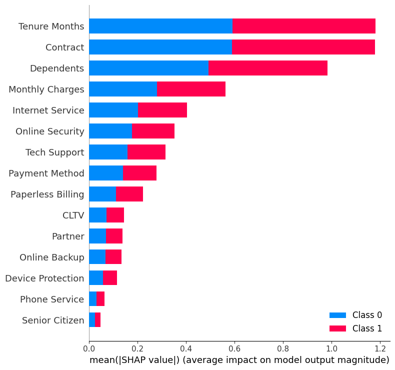

```python
shap.summary_plot(shap_values, X_test)
```

Aunque este gráfico superior sea interesante, el siguiente será el analizado ya que nos brinda aún más información sobre la manera en la que el modelo toma decisiones en base a los valores de cada una de las variables que lo componen:

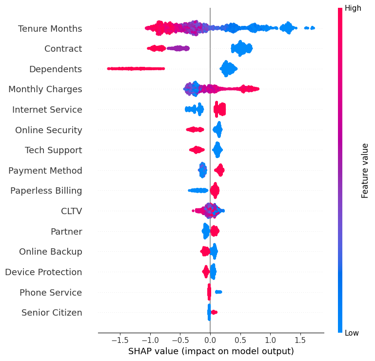

```python
shap.summary_plot(shap_values[1], features=X_test, max_display=30)
```

En este gráfico se puede observar claramente como influye cada variable en el modelo, con la direciconalidad también explícita en este caso. A continuación la explicación de las principales variables:

1. La primer variable a mencionar es la variable treatment (Tech Support) que, como se vio tanto en el análisis causal como en los gráficos de dependencia parcial, tiene un claro efecto negativo en propención a fuga. Es decir, que si se posee el servicio técnico premium, es menos probable que el cliente deje la compañía, aunque su efecto no es tan significativo como el de otras variables.
2. Efecto que si es signficativo es el de los meses de estancia con el servicio (Tenure Months), ya que claramente se puede notar como los clientes que mayor cantidad de meses llevan en la compañía tienen una menor propención a abandonar el servicio.
3. Lo mismo sucede con el tipo de contrato, que también está claramente relacionado, ya que contratos de menor duración tienen mucha mayor propención a la fuga que contratos de mayor duración.
4. Dependents es una variable que también tiene su peso, sobre todo cuando sí se tienen personas a cargo, lo que genera que la propención a la fuga sea mucho menor.
5. Lo inverso sucede con los cargos mensuales, es decir, mientras mayor sea el cargo por mes, parece que más probable es que el cliente abandone la compañía.
6. No es cuestión de enumerar cada uno de las variables, pero la última que se ha de mencionar es el CLTV, la cual a priori parecería importante pero la verdad es que no parece tener mucha relevancia en el modelo.

## Interpretabilidad de variables en Regresión Logística

Al igual que se han evaluado la importancia de las variables en el modelo LightGBM, también se puede medir esa importancia en la Regresión Logística. Y no solo eso, al tratarse de un modelo paramétrico lineal, la interpretabilidad general del modelo es tan transparente que se condice a su vez con la explicabilidad local, pudiendo saber la manera exacta en la que afecta cada valor de cada variable a la decisión final del modelo.

```python
coefs_lr = pd.DataFrame(lr.coef_.T, index=X_train.columns, columns=['Coeficientes'])
coefs_lr['Coeficientes_abs'] = coefs_lr['Coeficientes'].abs()
coefs_lr = coefs_lr.sort_values(by='Coeficientes_abs', ascending=False)
coefs_lr = coefs_lr.drop('Coeficientes_abs', axis=1)
coefs_lr.reset_index(names='Variable', inplace=True)

coefs_lr.style.background_gradient(cmap='coolwarm')
```

|  | Variable | Coeficientes |
| --- | --- | --- |
| 0 | Dependents | -1.486127 |
| 1 | Payment Method | 1.083130 |
| 2 | Phone Service | -0.874405 |
| 3 | Tenure Months | -0.805904 |
| 4 | Contract | -0.630626 |
| 5 | Monthly Charges | 0.580038 |
| 6 | Online Security | -0.513560 |
| 7 | Tech Support | -0.461023 |
| 8 | Paperless Billing | 0.338351 |
| 9 | Device Protection | -0.269728 |
| 10 | Online Backup | -0.249122 |
| 11 | Internet Service | 0.234573 |
| 12 | Partner | 0.207255 |
| 13 | Senior Citizen | 0.105413 |
| 14 | CLTV | 0.014996 |

En este caso podemos ver que las variables más importantes para el modelo son las personas a cargo (Dependents) y el método de pago, lo cual es curioso porque, a pesar de contar con cierta importancia, no son las mismas dos variables principales que tenía en cuenta el modelo de LightGBM. En este caso la direccionalidad es la misma, disminuyendo la propención cuando dependents es 1, y aumentando cuando el payment method es mayor (y por ende es pago mediante boleta electrónica). En cuanto a la variable tratamiento, también se la puede observar con una importancia media y claramente negativa en relación a la propención a fuga del cliente cuando se posee el servicio técnico premium. No es cuestión de analizar todas las variables de la misma manera, pero si se ha de comentar que, a pesar de estar relativamente en concordancia con el modelo LightGBM, hay algunas variables cuya importancia si que cambia, como puede serlo Phone Service, que en este modelo tiene bastante más relevancia que en el anterior.

Además de revisar la regresión logística, se hace una prueba comparativa a modo de curiosidad con la regresión lineal, principalmente porque los coeficientes de esta si que son transparentes, como se expuso en el análisis causal:

```python
linreg = LinearRegression()
linreg.fit(X_train, y_train)
```

```
LinearRegression()
```

```python
coefs_linreg = pd.DataFrame(linreg.coef_.T, index=X_train.columns, columns=['Coeficientes'])
coefs_linreg['Coeficientes_abs'] = coefs_linreg['Coeficientes'].abs()
coefs_linreg = coefs_linreg.sort_values(by='Coeficientes_abs', ascending=False)
coefs_linreg = coefs_linreg.drop('Coeficientes_abs', axis=1)
coefs_linreg.reset_index(names='Variable', inplace=True)

coefs_linreg.style.background_gradient(cmap='coolwarm')
```

|  | Variable | Coeficientes |
| --- | --- | --- |
| 0 | Payment Method | 0.248770 |
| 1 | Dependents | -0.178540 |
| 2 | Tenure Months | -0.139962 |
| 3 | Phone Service | -0.120774 |
| 4 | Monthly Charges | 0.084061 |
| 5 | Online Security | -0.071523 |
| 6 | Tech Support | -0.069203 |
| 7 | Internet Service | 0.052033 |
| 8 | Paperless Billing | 0.049483 |
| 9 | Device Protection | -0.044684 |
| 10 | Contract | -0.040058 |
| 11 | Online Backup | -0.038996 |
| 12 | Partner | 0.029428 |
| 13 | Senior Citizen | 0.026555 |
| 14 | CLTV | 0.004620 |

```python
coefs = pd.merge(coefs_lr, coefs_linreg, on='Variable', suffixes=('_lr', '_linreg'))
coefs.style.background_gradient(cmap='coolwarm')
```

|  | Variable | Coeficientes_lr | Coeficientes_linreg |
| --- | --- | --- | --- |
| 0 | Dependents | -1.486127 | -0.178540 |
| 1 | Payment Method | 1.083130 | 0.248770 |
| 2 | Phone Service | -0.874405 | -0.120774 |
| 3 | Tenure Months | -0.805904 | -0.139962 |
| 4 | Contract | -0.630626 | -0.040058 |
| 5 | Monthly Charges | 0.580038 | 0.084061 |
| 6 | Online Security | -0.513560 | -0.071523 |
| 7 | Tech Support | -0.461023 | -0.069203 |
| 8 | Paperless Billing | 0.338351 | 0.049483 |
| 9 | Device Protection | -0.269728 | -0.044684 |
| 10 | Online Backup | -0.249122 | -0.038996 |
| 11 | Internet Service | 0.234573 | 0.052033 |
| 12 | Partner | 0.207255 | 0.029428 |
| 13 | Senior Citizen | 0.105413 | 0.026555 |
| 14 | CLTV | 0.014996 | 0.004620 |

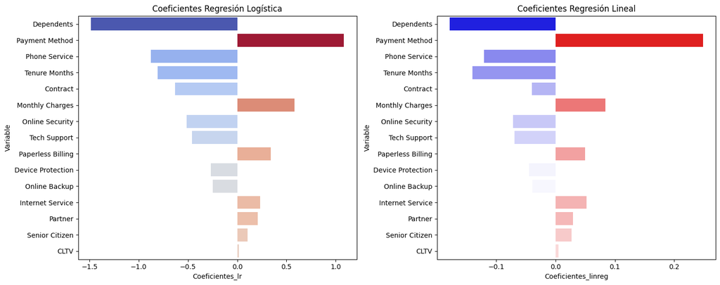

```python
# gráfico de barras laterales con importancia por variable

fig, ax = plt.subplots(1, 2, figsize=(15, 6))

sns.barplot(x='Coeficientes_lr', y='Variable', data=coefs, ax=ax[0], hue='Coeficientes_lr', palette='coolwarm', legend=False)
ax[0].set_title('Coeficientes Regresión Logística')

sns.barplot(x='Coeficientes_linreg', y='Variable', data=coefs, ax=ax[1], hue='Coeficientes_lr', palette='bwr', legend=False)
ax[1].set_title('Coeficientes Regresión Lineal')

plt.tight_layout()
plt.show()
```

Es bueno confirmar que en ambos casos las tendencias son muy similares, sobre todo en cuanto a la variable tratamiento se refiere, aunque solo se ha de destacar que la regresión lineal otorga una mayor preponderancia al método de pago que a los dependientes y a Tenure Months por sobre Phone Service, probablemente debido a que este modelo absorve menos la importancia de variables discretas.

Finalmente, se muestra como se puede obtener el score de la regresión logística calculando manualmente el resultado del modelo si se cuenta con los coeficientes y con los valores de un individuo:

```python
# calculo la proba a mano de una instancia de prueba, en este caso la 0:

value_pre_logit = X_test.iloc[0] @ lr.coef_.T + lr.intercept_ # se realiza el producto punto entre los coeficientes y la instancia de prueba

proba_logit = 1 / (1 + np.exp(-value_pre_logit)) # se aplica la función logística

proba_logit # propención a fuga de la instancia de prueba
```

```
array([0.84932012])
```

```python
lr.predict_proba(X_test.iloc[0:1])[0][1]
```

$\displaystyle 0.84932012470933$

Vemos como el resultado al que se llega con el cálculo manual y con el cálculo del modelo es exáctamente el mismo. No es menor tener en cuenta que los coeficientes de por sí no tienen el impacto directo, sino que a eso hay que pasarlo por la función logit para obtener el score final.

En cambio con una regresión lineal, el cálculo es directo:

```python
# Lo mismo pero con la regresión lineal
X_test.iloc[0] @ linreg.coef_.T + linreg.intercept_
```

$\displaystyle 0.783290120634923$

```python
linreg.predict(X_test.iloc[0:1])[0]
```

$\displaystyle 0.783290120634923$

# Clustering con Shap Values

Además de los análisis de explicabilidad e interpretabilidad, se ha decidido ir más allá e intentar exponer una manera de brindar valor agregado a los resultados de los modelos mediante el uso de una metodología de clustering. Con este procedimiento se buscará inferir de qué manera se comportan grupos de clientes propensos a la fuga, con el fin de brindar inputs más potentes y personalizados a negocio para que pueda idear acciones de retención. Lo interesante del análisis será exponer como es posible generar una sinergia entre los resultados de los análisis predictivos, causal y de explicabilidad para brindar información valiosa a negocio.

El primer paso es generar un dataframe nuevo con todos los shap values generados:

```python
shap_df = pd.DataFrame(shap_values[1], columns=X_test.columns.values)
shap_df
```

|  | Tenure Months | Monthly Charges | CLTV | Contract | Payment Method | Senior Citizen | Partner | Dependents | Phone Service | Internet Service | Online Security | Online Backup | Device Protection | Tech Support | Paperless Billing |
| --- | --- | --- | --- | --- | --- | --- | --- | --- | --- | --- | --- | --- | --- | --- | --- |
| 0 | 1.325188 | 0.189181 | -0.091292 | 0.647987 | 0.162733 | 0.056494 | -0.039988 | 0.271351 | -0.012665 | 0.171363 | 0.132867 | 0.045146 | 0.073548 | 0.134959 | 0.118877 |
| 1 | -0.135027 | 0.659343 | -0.036278 | 0.484048 | 0.175819 | -0.011773 | 0.062511 | 0.322681 | -0.009823 | 0.205892 | -0.276606 | 0.103307 | 0.060765 | -0.219451 | 0.051125 |
| 2 | 0.714732 | -0.227133 | 0.147296 | 0.532194 | 0.173348 | -0.015451 | -0.065081 | 0.228755 | 0.109089 | -0.288375 | 0.126829 | 0.071398 | 0.027109 | 0.092414 | -0.227641 |
| 3 | -0.782496 | -0.075691 | 0.002116 | -0.874856 | 0.162738 | -0.007157 | 0.089595 | 0.297989 | -0.020648 | -0.174014 | -0.273002 | -0.074791 | -0.068402 | -0.236550 | -0.099252 |
| 4 | -0.736274 | 0.557452 | 0.069687 | -0.609141 | -0.078756 | -0.009587 | 0.059549 | -1.510136 | -0.016862 | 0.084224 | 0.076870 | -0.113764 | -0.048465 | -0.140606 | -0.112180 |
| ... | ... | ... | ... | ... | ... | ... | ... | ... | ... | ... | ... | ... | ... | ... | ... |
| 1099 | -0.846779 | 0.742579 | -0.212130 | -0.927002 | -0.121552 | -0.008752 | 0.061547 | 0.327206 | -0.016812 | 0.105198 | -0.282481 | 0.061910 | -0.071360 | -0.218916 | 0.037938 |
| 1100 | 1.292425 | -0.244576 | 0.080026 | 0.544817 | -0.152508 | -0.020460 | -0.039694 | 0.233537 | 0.109089 | -0.256079 | 0.148247 | 0.052373 | 0.028538 | 0.122228 | 0.080855 |
| 1101 | -0.554829 | -0.226417 | -0.022648 | -0.495737 | -0.109937 | -0.015390 | 0.050651 | -1.464852 | -0.017665 | -0.149330 | 0.098526 | 0.055978 | -0.051623 | 0.125069 | 0.051495 |
| 1102 | 1.264332 | -0.249690 | 0.089510 | 0.560497 | 0.187116 | -0.014307 | -0.039694 | 0.246421 | -0.016194 | -0.259676 | 0.152269 | 0.077212 | 0.034122 | 0.125363 | 0.085152 |
| 1103 | -0.322102 | -0.345179 | -0.045093 | 0.378151 | -0.129793 | -0.021117 | -0.080891 | 0.328895 | -0.021138 | -0.353501 | 0.146517 | -0.070119 | -0.037153 | 0.143822 | 0.108275 |

1104 rows × 15 columns

```python
shap_4cluster = pd.concat([shap_df, y_test.reset_index(drop=True)], axis=1)
```

Una vez ordenados los shap values, se procede a realizar el filtrado en donde solo quedan los clientes que han dejado la compañía en el último trimestre:

```python
shap1 = shap_4cluster[shap_4cluster['Churn Value']==1]
```

Luego, se procede a ejecutar un modelo no supervisado de K-Means, el cual permitirá generar clusters de clientes. En este caso se procede a correr 10 veces secuancialmente a dicho modelo, aumentando en 1 la cantidad de clusters en cada iteración. De esta manera se obtiene un gráfico de codo, que nos permite visualizar cual es el número óptimo de clusters en base a cuánto aporta cada nueva inclusión:

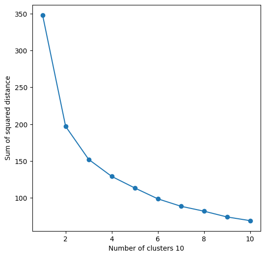

```
CPU times: total: 344 ms
Wall time: 524 ms
```

```python
%%time
fr.k_means_search(df=shap1, clusters_max=10)
```

En este caso el número de clusters elegido será 3.

```python
km = KMeans(n_clusters=3)
km.fit(shap1)
```

```
KMeans(n_clusters=3)
```

Una vez entrenado el modelo, se procede a determinar el cluster al que pertenecerá cada instancia del dataset de clientes fugados:

```python
km_coefs = km.transform(shap1)
```

```python
cluster = []
for i in km_coefs:
    cluster.append(i.argmax())
```

```python
km_coefs
```

```
array([[0.4995537 , 2.22306566, 1.40317441],
       [1.53318787, 1.25041939, 0.7567449 ],
       [1.25816172, 1.44316804, 0.54548529],
       ...,
       [2.65604836, 0.75410906, 1.84454016],
       [0.47776036, 2.24111296, 1.45056058],
       [0.43853415, 2.23078275, 1.41267029]])
```

```python
len(cluster)
```

$\displaystyle 351$

```python
km_coefs.shape
```

$\displaystyle \left( 351, \ 3\right)$

```python
shap1['cluster'] = np.array(cluster) + 1 # para que el nro de clusters vaya del 1 al 3 en vez del 0 al 2
```

```python
display(df_cates[df_cates.y_true==1].head(), df_cates[df_cates.y_true==1].shape)
```

|  | y_pred_proba | index | y_true | CATE | CLTV |
| --- | --- | --- | --- | --- | --- |
| 0 | 0.877256 | 515 | 1 | -0.218639 | 5536 |
| 1 | 0.554158 | 597 | 1 | -0.085369 | 3425 |
| 6 | 0.522660 | 1544 | 1 | -0.165456 | 3853 |
| 12 | 0.564108 | 868 | 1 | -0.137943 | 6204 |
| 16 | 0.080167 | 1285 | 1 | 0.016397 | 2313 |

$\displaystyle \left( 351, \ 5\right)$

Una vez determinados los clusters, se procede a agregarlos al dataframe etiquetando a cada instancia con su cluster correspondiente. Además, se suman a este dataframe los valores de la predicción de fuga y del CATE.

```python
churns = df_test[df_test['Churn Value']==1]
churns['cluster'] = np.array(cluster) + 1
churns['CATE'] = df_cates.set_index(df_cates['index'].values).CATE
churns['churn_proba'] = df_cates.set_index(df_cates['index'].values).y_pred_proba
churns['CLTV'] = df_cates.set_index(df_cates['index'].values).CLTV
```

```python
df_test_raw = pd.read_parquet('../data/ibm_telco_churn/df_telco_test.parquet')
df_test_raw = df_test_raw[df_test_raw['Churn Value']==1]
display(df_test_raw.head(), df_test_raw.shape)
```

|  | CustomerID | Count | Country | State | City | Zip Code | Lat Long | Latitude | Longitude | Gender | Senior Citizen | Partner | Dependents | Tenure Months | Phone Service | Multiple Lines | Internet Service | Online Security | Online Backup | Device Protection | Tech Support | Streaming TV | Streaming Movies | Contract | Paperless Billing | Payment Method | Monthly Charges | Total Charges | Churn Label | … |
| --- | --- | --- | --- | --- | --- | --- | --- | --- | --- | --- | --- | --- | --- | --- | --- | --- | --- | --- | --- | --- | --- | --- | --- | --- | --- | --- | --- | --- | --- | --- |
| 515 | 9497-QCMMS | 1 | United States | California | Escondido | 92026 | 33.21846, -117.116916 | 33.218460 | -117.116916 | Male | Yes | No | No | 1 | Yes | Yes | Fiber optic | No | No | No | No | Yes | Yes | Month-to-month | Yes | Electronic check | 93.55 | 93.55 | Yes | … |
| 597 | 0320-JDNQG | 1 | United States | California | Oxnard | 93035 | 34.18454, -119.224666 | 34.184540 | -119.224666 | Male | No | Yes | No | 23 | Yes | No | Fiber optic | Yes | No | No | Yes | Yes | Yes | Month-to-month | Yes | Electronic check | 99.85 | 2331.30 | Yes | … |
| 1544 | 3398-ZOUAA | 1 | United States | California | Redwood City | 94063 | 37.499411, -122.196318 | 37.499411 | -122.196318 | Male | Yes | Yes | No | 21 | Yes | No | Fiber optic | No | No | No | No | No | No | Month-to-month | Yes | Electronic check | 69.10 | 1474.75 | Yes | … |
| 868 | 8276-MQBYC | 1 | United States | California | Los Angeles | 90028 | 34.099869, -118.326843 | 34.099869 | -118.326843 | Male | Yes | No | No | 51 | Yes | Yes | Fiber optic | No | No | Yes | No | Yes | Yes | Month-to-month | Yes | Electronic check | 97.80 | 4913.30 | Yes | … |
| 1285 | 6635-MYYYZ | 1 | United States | California | Trinity Center | 96091 | 41.081847, -122.700545 | 41.081847 | -122.700545 | Female | No | No | No | 30 | Yes | No | DSL | Yes | Yes | Yes | Yes | Yes | Yes | One year | No | Bank transfer (automatic) | 85.35 | 2530.40 | Yes | … |

$\displaystyle \left( 351, \ 33\right)$

```python
churns['Tenure Months original'] = df_test_raw['Tenure Months'].values
```

```python
display(churns.head(), churns.shape)
```

|  | Tenure Months | Monthly Charges | CLTV | Contract | Payment Method | Senior Citizen | Partner | Dependents | Phone Service | Internet Service | Online Security | Online Backup | Device Protection | Tech Support | Paperless Billing | Churn Value | cluster | CATE | churn_proba | Tenure Months original |
| --- | --- | --- | --- | --- | --- | --- | --- | --- | --- | --- | --- | --- | --- | --- | --- | --- | --- | --- | --- | --- |
| 515 | -1.299099 | 0.763577 | 0.954330 | 0.0 | 0.471083 | 1.0 | 0.0 | 0.0 | 1.0 | 1.0 | 0.0 | 0.0 | 0.0 | 0.0 | 1.0 | 1 | 2 | -0.218639 | 0.877256 | 1 |
| 597 | -0.403202 | 1.051797 | -0.835391 | 0.0 | 0.471083 | 0.0 | 1.0 | 0.0 | 1.0 | 1.0 | 1.0 | 0.0 | 0.0 | 1.0 | 1.0 | 1 | 1 | -0.085369 | 0.554158 | 23 |
| 1544 | -0.484648 | -0.354990 | -0.472530 | 0.0 | 0.471083 | 1.0 | 1.0 | 0.0 | 1.0 | 1.0 | 0.0 | 0.0 | 0.0 | 0.0 | 1.0 | 1 | 2 | -0.165456 | 0.522660 | 21 |
| 868 | 0.737030 | 0.958011 | 1.520665 | 0.0 | 0.471083 | 1.0 | 0.0 | 0.0 | 1.0 | 1.0 | 0.0 | 0.0 | 1.0 | 0.0 | 1.0 | 1 | 1 | -0.137943 | 0.564108 | 51 |
| 1285 | -0.118144 | 0.388434 | -1.778153 | 1.0 | 0.196576 | 0.0 | 0.0 | 0.0 | 1.0 | 0.0 | 1.0 | 1.0 | 1.0 | 1.0 | 0.0 | 1 | 1 | 0.016397 | 0.080167 | 30 |

$\displaystyle \left( 351, \ 20\right)$

A partir de este dataset se desarrollará un breve EDA en el que se verificarán las principales características de cada cluster generado por el modelo K-Means:

```python
bools, cats, nums = fr.tipos_vars(df=churns)
```

```
(numeric) - Tenure Months : Range = [-1.30 to 1.55], Mean = -0.57
(numeric) - Monthly Charges : Range = [-2.38 to 1.90], Mean = 0.03
(numeric) - CLTV : Range = [-2.04 to 1.59], Mean = -0.24
(categoric)(Type: float64) - Contract : ['0.0', '1.0', '2.0']
(categoric)(Type: float64) - Payment Method : ['0.19002203497669012', '0.19657560638775337', '0.2720145891204114', '0.4710826343827463']
(boolean) - Senior Citizen :  [1. 0.]
(boolean) - Partner :  [0. 1.]
(boolean) - Dependents :  [0. 1.]
(boolean) - Phone Service :  [1. 0.]
(boolean) - Internet Service :  [1. 0.]
(boolean) - Online Security :  [0. 1.]
(boolean) - Online Backup :  [0. 1.]
(boolean) - Device Protection :  [0. 1.]
(boolean) - Tech Support :  [0. 1.]
(boolean) - Paperless Billing :  [1. 0.]
(boolean) - Churn Value :  [1]
(boolean) - cluster :  [2 1]
(numeric) - CATE : Range = [-0.27 to 0.11], Mean = -0.11
(numeric) - churn_proba : Range = [0.03 to 0.89], Mean = 0.53
(numeric) - Tenure Months original : Range = [1.00 to 71.00], Mean = 18.96
```

```python
churns.cluster.value_counts()
```

```
cluster
2    227
1    124
Name: count, dtype: int64
```

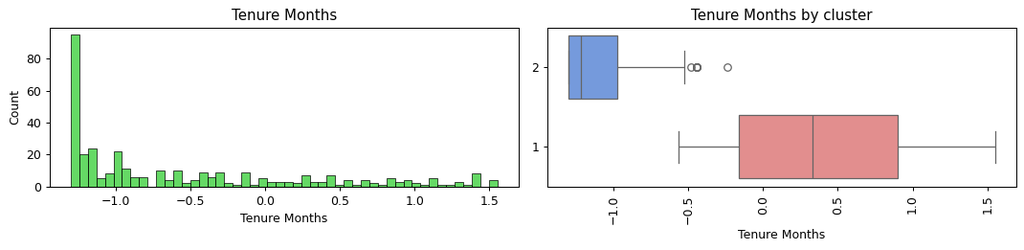

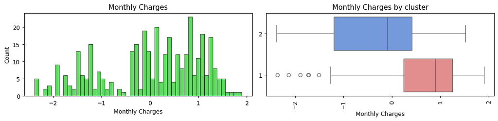

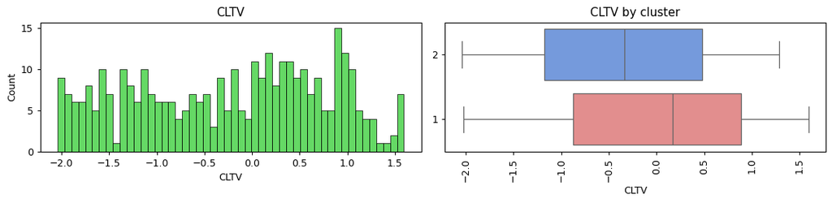

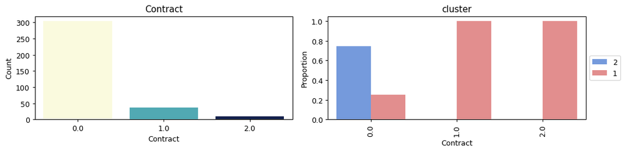

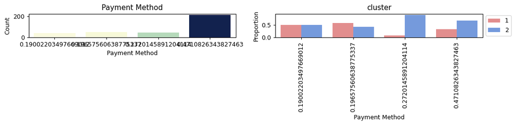

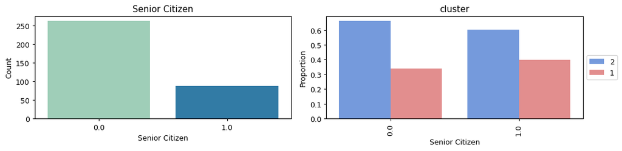

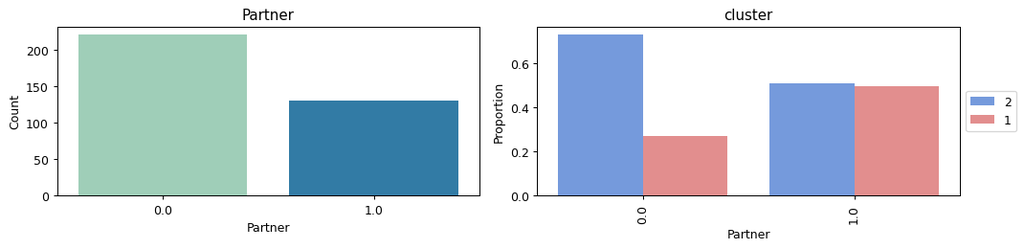

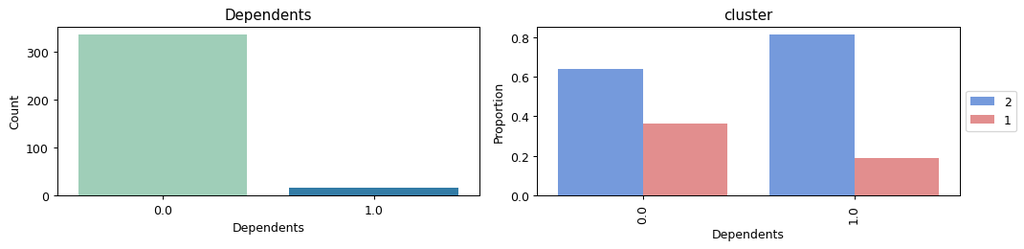

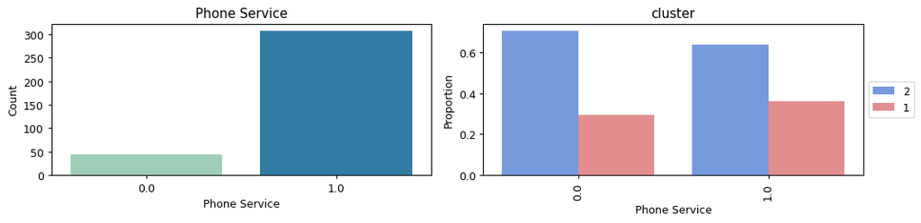

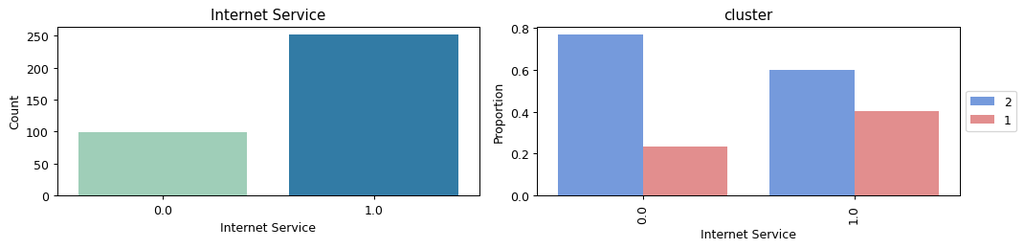

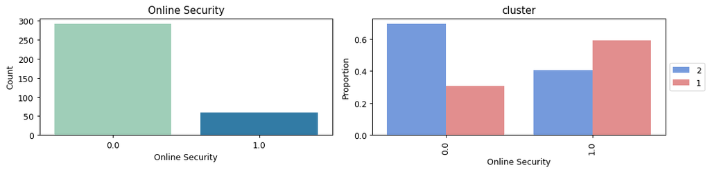

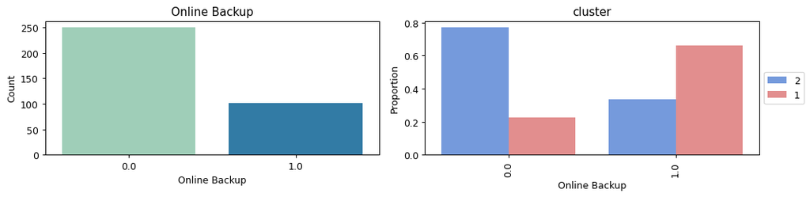

[7 more figures not shown]

```python
warnings.filterwarnings('ignore')
for i in list(churns.columns):
   if i in nums:
       fr.double_plot(churns
                     ,col_name=i
                     ,is_cont=True
                     ,target='cluster'
                     ,palette={churns.cluster.unique()[0].astype('str'):'cornflowerblue'
                              ,churns.cluster.unique()[1].astype('str'):'lightcoral'}
                     ,y_scale='linear')
   elif  ((i in bools) | (i in cats)) & (i!='cluster'):
       fr.double_plot(churns
                     ,col_name=i
                     ,is_cont=False
                     ,target='cluster'
                     ,palette={churns.cluster.unique()[0].astype('str'):'cornflowerblue'
                              ,churns.cluster.unique()[1].astype('str'):'lightcoral'}
                     ,y_scale='linear')
```

```python
churns.loc[churns.cluster==1, 'Tenure Months original'].median(), churns.loc[churns.cluster==2, 'Tenure Months original'].median()
```

$\displaystyle \left( 41.0, \ 3.0\right)$

## Análisis de clusters:

Todas estas características dejan bastante en claro las diferencias entre ambos clusters, pero antes de dar las recomendaciones finales, se procede a mostrar nuevamente los gráficos que combinan las predicciones del CATE y de la propención a fuga:

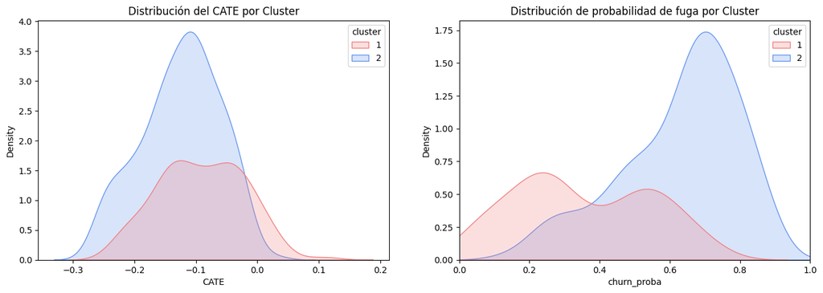

```python
fig, (ax1, ax2) = plt.subplots(1, 2, figsize=(16,5))

sns.kdeplot(data=churns
            ,x='CATE'
            ,hue='cluster'
            ,palette={churns.cluster.unique()[0]:'cornflowerblue'
                     ,churns.cluster.unique()[1]:'lightcoral'}
            ,fill=True
            ,ax=ax1)

ax1.set_title('Distribución del CATE por Cluster')

sns.kdeplot(data=churns
            ,x='churn_proba'
            ,hue='cluster'
            ,palette={churns.cluster.unique()[0]:'cornflowerblue'
                     ,churns.cluster.unique()[1]:'lightcoral'}
            ,fill=True
            ,ax=ax2)

ax2.set_title('Distribución de probabilidad de fuga por Cluster')
ax2.set_xlim(0,1)

plt.show()
```

```python
churns.describe().T
```

|  | count | mean | std | min | 25% | 50% | 75% | max |
| --- | --- | --- | --- | --- | --- | --- | --- | --- |
| Tenure Months | 351.0 | -0.567717 | 0.824246 | -1.299099 | -1.258377 | -0.932596 | -0.097783 | 1.551481 |
| Monthly Charges | 351.0 | 0.027381 | 1.018690 | -2.383966 | -0.774739 | 0.164263 | 0.835632 | 1.898157 |
| CLTV | 351.0 | 4121.504274 | 1177.975677 | 2003.000000 | 3059.500000 | 4254.000000 | 5082.000000 | 6289.000000 |
| Contract | 351.0 | 0.162393 | 0.439947 | 0.000000 | 0.000000 | 0.000000 | 0.000000 | 2.000000 |
| Payment Method | 351.0 | 0.372826 | 0.125130 | 0.190022 | 0.196576 | 0.471083 | 0.471083 | 0.471083 |
| Senior Citizen | 351.0 | 0.250712 | 0.434042 | 0.000000 | 0.000000 | 0.000000 | 0.500000 | 1.000000 |
| Partner | 351.0 | 0.370370 | 0.483593 | 0.000000 | 0.000000 | 0.000000 | 1.000000 | 1.000000 |
| Dependents | 351.0 | 0.045584 | 0.208879 | 0.000000 | 0.000000 | 0.000000 | 0.000000 | 1.000000 |
| Phone Service | 351.0 | 0.874644 | 0.331595 | 0.000000 | 1.000000 | 1.000000 | 1.000000 | 1.000000 |
| Internet Service | 351.0 | 0.717949 | 0.450641 | 0.000000 | 0.000000 | 1.000000 | 1.000000 | 1.000000 |
| Online Security | 351.0 | 0.168091 | 0.374481 | 0.000000 | 0.000000 | 0.000000 | 0.000000 | 1.000000 |
| Online Backup | 351.0 | 0.287749 | 0.453360 | 0.000000 | 0.000000 | 0.000000 | 1.000000 | 1.000000 |
| Device Protection | 351.0 | 0.378917 | 0.485810 | 0.000000 | 0.000000 | 0.000000 | 1.000000 | 1.000000 |
| Tech Support | 351.0 | 0.182336 | 0.386673 | 0.000000 | 0.000000 | 0.000000 | 0.000000 | 1.000000 |
| Paperless Billing | 351.0 | 0.760684 | 0.427275 | 0.000000 | 1.000000 | 1.000000 | 1.000000 | 1.000000 |
| Churn Value | 351.0 | 1.000000 | 0.000000 | 1.000000 | 1.000000 | 1.000000 | 1.000000 | 1.000000 |
| cluster | 351.0 | 1.646724 | 0.478670 | 1.000000 | 1.000000 | 2.000000 | 2.000000 | 2.000000 |
| CATE | 351.0 | -0.112962 | 0.067664 | -0.266142 | -0.156599 | -0.110770 | -0.061537 | 0.109203 |
| churn_proba | 351.0 | 0.530599 | 0.221165 | 0.025864 | 0.338235 | 0.571737 | 0.705474 | 0.892173 |

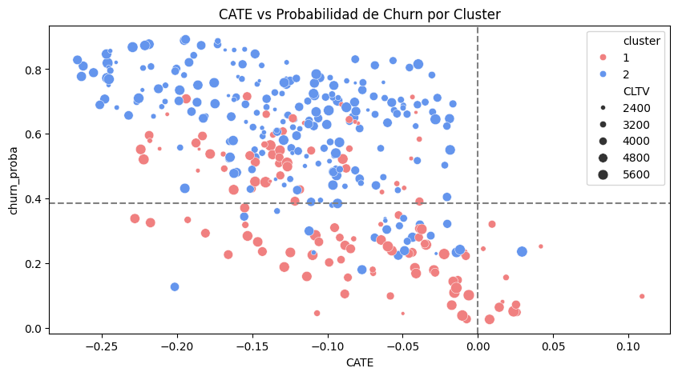

```python
fig, ax = plt.subplots(figsize=(10,5))

sns.scatterplot(data=churns
                ,x='CATE'
                ,y='churn_proba'
                ,hue='cluster'
                ,palette={churns.cluster.unique()[0]:'cornflowerblue'
                         ,churns.cluster.unique()[1]:'lightcoral'}
                ,ax=ax
                ,size='CLTV'
                ,sizes=(10, 100)
                )

lgbm_threshold = 0.385 # threshold balanceado del modelo LGBM

ax.axhline(y=lgbm_threshold, color='grey', linestyle='--')
ax.axvline(x=0, color='grey', linestyle='--')

ax.set_title('CATE vs Probabilidad de Churn por Cluster')

plt.show()
```

# Recomendaciones finales de negocio:

Por último, se procede a guardar los datasets resultantes:

```python
shap_df.to_parquet('../data/ibm_telco_churn/processed/shap_values.parquet')
churns.to_parquet('../data/ibm_telco_churn/processed/churns_df.parquet')
```